# Job Postings Collapse in Key Sectors — Are We Entering a Labor Market Cooldown?

Recently, various news outlets have reported widespread anxiety in the U.S. labor market. This collective feeling is fed by the uncertainty brought by the Trump administration, coupled with the threat of a looming recession.

In this project, I use job postings data fron different sources to document recent movements in the U.S. labor markets.

## 0. Preparation

I downloaded the datasets from the provided links:

- Job Postings Data: This data describes LinkedIn job vacancies and links each posting back to a company and its parent group. The structure mirrors the same raw-plus-mapped pattern you’ve been showing: raw titles, translated titles, hierarchical role categories, industry codes, geography, salary, and the dates the posting appeared or was removed.

  **Fields:** job_id, rcid, company, rics_k50, rics_k200, rics_k400, title_raw, title_translated, role_k10, role_k50, role_k150, role_k1500, mapped_role, country, state, salary, post_date, remove_date, ultimate_parent_rcid, ultimate_parent_company_name, remove_type.

For this exercise, I use the LinkedIn Job Postings data with additional macroeconomic variables.

```python
#Housekeeping
import sys
import os
#Import functions stored in a folder (custom)
import sys
#sys.path.append("directoryname")
import time
import pandas as pd
import numpy as np
from glob import glob
import seaborn as sns
from scipy import stats
import pyreadstat
import matplotlib.pyplot as plt

clear = lambda: os.system('cls')
clear()

#Define main path and output path to export results
os.chdir('[[PATH]]')
out_path   = "./Output/"
os.makedirs(out_path, exist_ok=True)
#Function to automatically save each file
def save_and_show(out_path,filename):
    plt.savefig(out_path + filename, dpi=300, bbox_inches='tight')
    plt.show()
```

Here, I import a sample of each of these datasets to do some initial data exploration:

```python
#Import Sample of Datasets to see their patterns
postings_linkedin_individual  = pd.read_csv('./Data/postings_linkedin_individual/postings_linkedin_individual_0_0_0.csv')

#Print Datasets

#Tells us LinkedIn vacancies for individuals
display(postings_linkedin_individual.head(10))
display(postings_linkedin_individual.columns)
```

|  | job_id | rcid | company | rics_k50 | rics_k200 | rics_k400 | title_raw | title_translated | role_k10 | role_k50 | ... | role_k1500 | mapped_role | country | state | salary | post_date | remove_date | ultimate_parent_rcid | ultimate_parent_company_name | remote_type |
| --- | --- | --- | --- | --- | --- | --- | --- | --- | --- | --- | --- | --- | --- | --- | --- | --- | --- | --- | --- | --- | --- |
| 0 | 323493558100000000005 | 350953 | Microsoft Corp. | Information Technology Services | Enterprise Software and IT Services | Enterprise Software and Cloud Services | Product Marketing Manager (Multiple Roles, inc... | product marketing manager multiple roles inclu... | Sales and Marketing | Product Marketing | ... | Product Manager | Product Marketing | United States | Mississippi | 126104.087265 | 2022-10-02 | 2022-10-24 | 350953 | Microsoft Corp. | Fully in Office |
| 1 | 3958486090 | 1475220 | Google Cloud | Information Technology Services | Enterprise Software and IT Services | Enterprise Software and Cloud Services | Workday Solutions Consultant | workday solutions consultant | Project and IT Specialist | Systems Analyst | ... | HCM Systems Analyst | Workday Consultant | Ireland | Leinster | 72701.937145 | 2024-06-25 | 2024-07-31 | 766823 | Alphabet, Inc. | Fully in Office |
| 2 | 322561550000000000003 | 350953 | Microsoft Corp. | Information Technology Services | Enterprise Software and IT Services | Enterprise Software and Cloud Services | U.S. DPSS SR CATEGORY MANAGER | us dpss sr category manager | Sales and Marketing | E-commerce Brand Manager | ... | Retail Management | Global Retail Director | United States | Alabama | 114703.959755 | 2022-09-03 | 2022-09-19 | 350953 | Microsoft Corp. | Fully in Office |
| 3 | 2569306356 | 350953 | Microsoft Corp. | Information Technology Services | Enterprise Software and IT Services | Enterprise Software and Cloud Services | Services Executive | services executive | Sales and Marketing | Sales Representative | ... | Sales Account Executive | Regional Account Executive | Australia | New South Wales | 99840.725230 | 2021-04-16 | 2021-05-16 | 350953 | Microsoft Corp. | Fully in Office |
| 4 | 2155368791 | 1233178 | Meta Platforms, Inc. | Digital Commerce Services | Digital Commerce Services | Tech and E-Commerce Platforms | Research Program Manager, FRL | research program manager frl | Project and IT Specialist | Project Consultant | ... | Program Manager | Sector Program Manager | United States | Washington | 124044.836609 | 2020-06-16 | 2020-08-12 | 1233178 | Meta Platforms, Inc. | Fully in Office |
| 5 | 2367598223 | 1233178 | Meta Platforms, Inc. | Digital Commerce Services | Digital Commerce Services | Tech and E-Commerce Platforms | Production Engineer | production engineer | Engineer | Engineer | ... | Manufacturing Engineer | Production Engineer | United States | Washington | 78150.000000 | 2020-12-21 | 2021-02-16 | 1233178 | Meta Platforms, Inc. | Fully in Office |
| 6 | 2688417147 | 350953 | Microsoft Corp. | Information Technology Services | Enterprise Software and IT Services | Enterprise Software and Cloud Services | Product Marketing Manager, Teams Usage - US M&O | product marketing manager teams usage us m a... | Sales and Marketing | Marketing Coordinator | ... | Content Marketing | Marketing Director | United States | Washington | 143389.448057 | 2021-08-23 | 2021-09-14 | 350953 | Microsoft Corp. | Fully in Office |
| 7 | 266713218300000000008 | 350953 | Microsoft Corp. | Information Technology Services | Enterprise Software and IT Services | Enterprise Software and Cloud Services | Service Engineer Azure Data Lake Storage - CTJ | service engineer azure data lake storage ctj | Software Engineer | Software Developer | ... | Infrastructure Engineer | Storage Engineer | United States | Washington | 130000.000000 | 2021-11-11 | 2021-11-18 | 350953 | Microsoft Corp. | Fully in Office |
| 8 | 368576882600000000009 | 1233178 | Meta Platforms, Inc. | Digital Commerce Services | Digital Commerce Services | Tech and E-Commerce Platforms | Software Engineer, Infrastructure - Monetization | software engineer, infrastructure monetization | Software Engineer | Software Developer | ... | Software Engineer | Software Engineering | United States | California | 155553.561120 | 2023-09-28 | 2023-10-01 | 1233178 | Meta Platforms, Inc. | Fully in Office |
| 9 | 3985339558 | 350953 | Microsoft Corp. | Information Technology Services | Enterprise Software and IT Services | Enterprise Software and Cloud Services | Principal Corporate Counsel, Land Acquisition,... | principal corporate counsel, land acquisition,... | Finance | Corporate Attorney | ... | Corporate Counsel | Mergers and Acquisitions Attorney | United States | Arkansas | 186100.000000 | 2024-07-27 | 2024-08-22 | 350953 | Microsoft Corp. | Fully in Office |

10 rows × 21 columns

```
Index(['job_id', 'rcid', 'company', 'rics_k50', 'rics_k200', 'rics_k400',
       'title_raw', 'title_translated', 'role_k10', 'role_k50', 'role_k150',
       'role_k1500', 'mapped_role', 'country', 'state', 'salary', 'post_date',
       'remove_date', 'ultimate_parent_rcid', 'ultimate_parent_company_name',
       'remote_type'],
      dtype='object')
```

## 1. Importing the Postings Dataset

```python
#Import Postings dataset fully. First, let's define filepaths
raw_path   = "./Data/postings_linkedin_individual/"
os.makedirs(raw_path, exist_ok=True)

csv_files = glob(os.path.join(raw_path, "*.csv"))

display(print(f"Found {len(csv_files)} raw postings files."))

#Append all data
dfs = []
for file in csv_files:
    print("Loading:", file)
    df = pd.read_csv(file)
    dfs.append(df)

# Append into a single DataFrame
postings = pd.concat(dfs, ignore_index=True)
print("Combined shape:", postings.shape)
display(postings)
```

```
Found 32 raw postings files.
```

```
None
```

```
Loading: ./Data/postings_linkedin_individual\postings_linkedin_individual_0_0_0.csv
Loading: ./Data/postings_linkedin_individual\postings_linkedin_individual_0_1_0.csv
Loading: ./Data/postings_linkedin_individual\postings_linkedin_individual_0_2_0.csv
Loading: ./Data/postings_linkedin_individual\postings_linkedin_individual_0_3_0.csv
Loading: ./Data/postings_linkedin_individual\postings_linkedin_individual_0_4_0.csv
Loading: ./Data/postings_linkedin_individual\postings_linkedin_individual_0_5_0.csv
Loading: ./Data/postings_linkedin_individual\postings_linkedin_individual_0_6_0.csv
Loading: ./Data/postings_linkedin_individual\postings_linkedin_individual_0_7_0.csv
Loading: ./Data/postings_linkedin_individual\postings_linkedin_individual_1_0_0.csv
Loading: ./Data/postings_linkedin_individual\postings_linkedin_individual_1_1_0.csv
Loading: ./Data/postings_linkedin_individual\postings_linkedin_individual_1_2_0.csv
Loading: ./Data/postings_linkedin_individual\postings_linkedin_individual_1_3_0.csv
Loading: ./Data/postings_linkedin_individual\postings_linkedin_individual_1_4_0.csv
Loading: ./Data/postings_linkedin_individual\postings_linkedin_individual_1_5_0.csv
Loading: ./Data/postings_linkedin_individual\postings_linkedin_individual_1_6_0.csv
Loading: ./Data/postings_linkedin_individual\postings_linkedin_individual_1_7_0.csv
Loading: ./Data/postings_linkedin_individual\postings_linkedin_individual_2_0_0.csv
Loading: ./Data/postings_linkedin_individual\postings_linkedin_individual_2_1_0.csv
Loading: ./Data/postings_linkedin_individual\postings_linkedin_individual_2_2_0.csv
Loading: ./Data/postings_linkedin_individual\postings_linkedin_individual_2_3_0.csv
Loading: ./Data/postings_linkedin_individual\postings_linkedin_individual_2_4_0.csv
Loading: ./Data/postings_linkedin_individual\postings_linkedin_individual_2_5_0.csv
Loading: ./Data/postings_linkedin_individual\postings_linkedin_individual_2_6_0.csv
Loading: ./Data/postings_linkedin_individual\postings_linkedin_individual_2_7_0.csv
Loading: ./Data/postings_linkedin_individual\postings_linkedin_individual_3_0_0.csv
Loading: ./Data/postings_linkedin_individual\postings_linkedin_individual_3_1_0.csv
Loading: ./Data/postings_linkedin_individual\postings_linkedin_individual_3_2_0.csv
Loading: ./Data/postings_linkedin_individual\postings_linkedin_individual_3_3_0.csv
Loading: ./Data/postings_linkedin_individual\postings_linkedin_individual_3_4_0.csv
Loading: ./Data/postings_linkedin_individual\postings_linkedin_individual_3_5_0.csv
Loading: ./Data/postings_linkedin_individual\postings_linkedin_individual_3_6_0.csv
Loading: ./Data/postings_linkedin_individual\postings_linkedin_individual_3_7_0.csv
Combined shape: (4308312, 21)
```

|  | job_id | rcid | company | rics_k50 | rics_k200 | rics_k400 | title_raw | title_translated | role_k10 | role_k50 | ... | role_k1500 | mapped_role | country | state | salary | post_date | remove_date | ultimate_parent_rcid | ultimate_parent_company_name | remote_type |
| --- | --- | --- | --- | --- | --- | --- | --- | --- | --- | --- | --- | --- | --- | --- | --- | --- | --- | --- | --- | --- | --- |
| 0 | 323493558100000000005 | 350953 | Microsoft Corp. | Information Technology Services | Enterprise Software and IT Services | Enterprise Software and Cloud Services | Product Marketing Manager (Multiple Roles, inc... | product marketing manager multiple roles inclu... | Sales and Marketing | Product Marketing | ... | Product Manager | Product Marketing | United States | Mississippi | 126104.087265 | 2022-10-02 | 2022-10-24 | 350953 | Microsoft Corp. | Fully in Office |
| 1 | 3958486090 | 1475220 | Google Cloud | Information Technology Services | Enterprise Software and IT Services | Enterprise Software and Cloud Services | Workday Solutions Consultant | workday solutions consultant | Project and IT Specialist | Systems Analyst | ... | HCM Systems Analyst | Workday Consultant | Ireland | Leinster | 72701.937145 | 2024-06-25 | 2024-07-31 | 766823 | Alphabet, Inc. | Fully in Office |
| 2 | 322561550000000000003 | 350953 | Microsoft Corp. | Information Technology Services | Enterprise Software and IT Services | Enterprise Software and Cloud Services | U.S. DPSS SR CATEGORY MANAGER | us dpss sr category manager | Sales and Marketing | E-commerce Brand Manager | ... | Retail Management | Global Retail Director | United States | Alabama | 114703.959755 | 2022-09-03 | 2022-09-19 | 350953 | Microsoft Corp. | Fully in Office |
| 3 | 2569306356 | 350953 | Microsoft Corp. | Information Technology Services | Enterprise Software and IT Services | Enterprise Software and Cloud Services | Services Executive | services executive | Sales and Marketing | Sales Representative | ... | Sales Account Executive | Regional Account Executive | Australia | New South Wales | 99840.725230 | 2021-04-16 | 2021-05-16 | 350953 | Microsoft Corp. | Fully in Office |
| 4 | 2155368791 | 1233178 | Meta Platforms, Inc. | Digital Commerce Services | Digital Commerce Services | Tech and E-Commerce Platforms | Research Program Manager, FRL | research program manager frl | Project and IT Specialist | Project Consultant | ... | Program Manager | Sector Program Manager | United States | Washington | 124044.836609 | 2020-06-16 | 2020-08-12 | 1233178 | Meta Platforms, Inc. | Fully in Office |
| ... | ... | ... | ... | ... | ... | ... | ... | ... | ... | ... | ... | ... | ... | ... | ... | ... | ... | ... | ... | ... | ... |
| 4308307 | 376866964500000000002 | 233459 | Google LLC | Digital Commerce Services | Digital Commerce Services | Tech and E-Commerce Platforms | Global Partner Go-to-Market Leader, Workspace,... | global partner go to market leader, workspace,... | Project and IT Specialist | Project Consultant | ... | Cloud Advisor | Cloud Business Manager | United States | Washington | 255334.677535 | 2023-12-05 | 2023-12-11 | 766823 | Alphabet, Inc. | Fully in Office |
| 4308308 | 2944948490 | 1233178 | Meta Platforms, Inc. | Digital Commerce Services | Digital Commerce Services | Tech and E-Commerce Platforms | Director, Compensation Business Partner, Reali... | director compensation business partner reality... | Finance | Claims Adjuster | ... | Compensation and Benefits | Executive Compensation | United States | California | 120065.543326 | 2022-02-28 | 2022-03-04 | 1233178 | Meta Platforms, Inc. | Fully in Office |
| 4308309 | 2759295280 | 350953 | Microsoft Corp. | Information Technology Services | Enterprise Software and IT Services | Enterprise Software and Cloud Services | Principal Software Engineer | principal software engineer | Software Engineer | Software Developer | ... | Software Engineer | Software Engineering | United States | North Carolina | 161000.000000 | 2021-09-23 | 2021-10-23 | 350953 | Microsoft Corp. | Fully in Office |
| 4308310 | 2599905190 | 1233178 | Meta Platforms, Inc. | Digital Commerce Services | Digital Commerce Services | Tech and E-Commerce Platforms | Computer Vision Silicon Architect | computer vision silicon architect | Software Engineer | Software Developer | ... | Computer Vision Engineer | Vision Engineer | United States | Texas | 191951.120577 | 2021-07-07 | 2021-08-20 | 1233178 | Meta Platforms, Inc. | Fully in Office |
| 4308311 | 314681742100000000004 | 1223555 | NVIDIA Corp. | Electronics Manufacturing | Electronics and Components Manufacturing | Semiconductor and Electronics Manufacturing | Senior Platform Architect – Autonomous Vehicles | senior platform architect autonomous vehicles | Software Engineer | Software Developer | ... | Robotics Engineer | Autonomous Software Engineer | United Kingdom | empty | 102236.850354 | 2022-08-19 | 2022-08-23 | 1223555 | NVIDIA Corp. | Fully in Office |

4308312 rows × 21 columns

Now, lets do some initial data cleaning, as well as frequency tables to get an idea of the data granularity:

```python
# Summarize the data (Numerical Variables)
display(postings.describe())

freq = (
    postings.groupby('mapped_role')
      .size()                # counts rows per mapped_role
      .reset_index(name='count')
)
print(freq.head(100))

freq = (
    postings.groupby('rics_k50')
      .size()                # counts rows per industry
      .reset_index(name='count')
)
print(freq.head(100))

freq = (
    postings.groupby('country')
      .size()                # counts rows per country
      .reset_index(name='count')
)
print(freq.head(100))

#Now let's parse the month dates
postings['post_date'] = pd.to_datetime(postings['post_date'], errors='coerce')
postings['remove_date'] = pd.to_datetime(postings['remove_date'], errors='coerce')

postings['post_quarter'] = postings['post_date'].dt.to_period('Q')
postings['remove_quarter'] = postings['remove_date'].dt.to_period('Q')

#Drop positions where the post and removal months are invalid and aggregate
postings = postings.dropna(subset=['post_quarter'])
postings = postings.dropna(subset=['remove_quarter'])
postings = postings[postings['country'] != 'empty']

#add job-post duration
postings['duration_days'] = (postings['remove_date'] - postings['post_date']).dt.days

#Create a Variable for US Vs Abroad
postings['country_group'] = np.where(
    postings['country'] == 'United States',
    'United States',
    'Abroad'
)
#Create a mapping to normalize presence
postings['remote_type_clean']= postings['remote_type'].str.strip().str.lower()

remote_map = {
    'fully remote': 'Remote',
    'remote in territory': 'Remote',
    'partially in office': 'Hybrid',
    'fully in office': 'Office'
}
postings['remote_group'] = postings['remote_type_clean'].map(remote_map)

#Filter to the US for the US plots
postings_usa = postings[postings['country'] == 'United States']

# Quick check
print(postings.shape)
#postings
```

|  | rcid | salary | ultimate_parent_rcid |
| --- | --- | --- | --- |
| count | 4.308312e+06 | 4.308009e+06 | 4.308312e+06 |
| mean | 8.057071e+05 | 1.240541e+05 | 7.682370e+05 |
| std | 1.943668e+06 | 5.663781e+04 | 1.250954e+06 |
| min | 7.000000e+00 | 1.000000e+00 | 3.509530e+05 |
| 25% | 3.509530e+05 | 8.384404e+04 | 3.509530e+05 |
| 50% | 3.509530e+05 | 1.263115e+05 | 3.509530e+05 |
| 75% | 1.233178e+06 | 1.647776e+05 | 1.233178e+06 |
| max | 1.018297e+08 | 8.771640e+05 | 2.214407e+07 |

```
                         mapped_role  count
0               .NET DevOps Engineer    294
1                     .NET Developer     39
2          .NET Full Stack Developer     50
3                    3D CAD Designer     15
4                         3D Creator    476
..                               ...    ...
95  Accessibility Compliance Auditor      1
96          Accessibility Consultant     81
97        Accessibility Data Analyst      2
98       Accessibility Product Owner    272
99     Accessibility Project Manager    532

[100 rows x 2 columns]
                                 rics_k50    count
```

[output cut: 34 more lines]

Now, I aggregate data to two different cuts:

1. type x quarter (US Data Only).
2. country x quarter

and supplement this data with other public data for comparison.

```python
grouping_type = ['post_quarter',  'rics_k50'   ]
grouping_count = ['post_quarter',  'country_group' ]

postings_quarterly_type = (
    postings_usa.groupby(grouping_type)
            .agg(
                postings=('job_id', 'count'),
                avg_salary=('salary', 'mean'),
                avg_duration_days=('duration_days', 'mean')
            )
            .reset_index()
)

#express in thousands openings
postings_quarterly_type['postings'] = postings_quarterly_type['postings']/1000
postings_quarterly_type['avg_salary'] = postings_quarterly_type['avg_salary']/1000
display(postings_quarterly_type)

postings_quarterly_country = (
    postings.groupby(grouping_count)
            .agg(
                postings=('job_id', 'count'),
                avg_salary=('salary', 'mean'),
                avg_duration_days=('duration_days', 'mean')
            )
            .reset_index()
)
postings_quarterly_country['postings'] = postings_quarterly_country['postings']/1000
postings_quarterly_country['avg_salary'] = postings_quarterly_country['avg_salary']/1000
display(postings_quarterly_country)
```

|  | post_quarter | rics_k50 | postings | avg_salary | avg_duration_days |
| --- | --- | --- | --- | --- | --- |
| 0 | 2020Q2 | Aerospace and Defense | 0.005 | 127.522810 | 57.000000 |
| 1 | 2020Q2 | Biotech and Healthcare Services | 0.024 | 92.333761 | 45.500000 |
| 2 | 2020Q2 | Digital Commerce Services | 17.347 | 122.676433 | 52.809419 |
| 3 | 2020Q2 | Electronics Manufacturing | 1.355 | 128.493850 | 39.053137 |
| 4 | 2020Q2 | Financial Services | 0.340 | 135.161774 | 40.050000 |
| ... | ... | ... | ... | ... | ... |
| 198 | 2025Q3 | Electronics Manufacturing | 2.325 | 242.462399 | 21.620645 |
| 199 | 2025Q3 | Financial Services | 0.282 | 177.118775 | 22.145390 |
| 200 | 2025Q3 | Information Technology Services | 13.386 | 179.629806 | 16.415434 |
| 201 | 2025Q3 | Media and Entertainment | 0.285 | 131.651700 | 24.750877 |
| 202 | 2025Q3 | Telecommunications Services | 0.061 | 117.115892 | 26.147541 |

203 rows × 5 columns

|  | post_quarter | country_group | postings | avg_salary | avg_duration_days |
| --- | --- | --- | --- | --- | --- |
| 0 | 2020Q2 | Abroad | 8.000 | 56.959048 | 35.682750 |
| 1 | 2020Q2 | United States | 24.426 | 125.530968 | 47.620077 |
| 2 | 2020Q3 | Abroad | 0.784 | 58.710923 | 34.204082 |
| 3 | 2020Q3 | United States | 1.601 | 129.414142 | 38.751405 |
| 4 | 2020Q4 | Abroad | 6.888 | 59.095396 | 37.583333 |
| 5 | 2020Q4 | United States | 19.325 | 136.683236 | 48.767400 |
| 6 | 2021Q1 | Abroad | 49.906 | 67.498552 | 33.861019 |
| 7 | 2021Q1 | United States | 77.221 | 143.825382 | 39.981767 |
| 8 | 2021Q2 | Abroad | 32.856 | 63.868718 | 33.847029 |
| 9 | 2021Q2 | United States | 58.293 | 141.808911 | 37.108624 |
| 10 | 2021Q3 | Abroad | 83.843 | 65.253131 | 21.535000 |
| 11 | 2021Q3 | United States | 351.688 | 150.260336 | 19.934291 |
| 12 | 2021Q4 | Abroad | 165.822 | 65.740650 | 19.092274 |
| 13 | 2021Q4 | United States | 850.501 | 145.915810 | 13.434701 |
| 14 | 2022Q1 | Abroad | 148.523 | 63.747705 | 15.263670 |
| 15 | 2022Q1 | United States | 472.499 | 138.649660 | 13.499783 |
| 16 | 2022Q2 | Abroad | 135.457 | 67.470264 | 12.020028 |
| 17 | 2022Q2 | United States | 284.757 | 138.361645 | 11.040491 |
| 18 | 2022Q3 | Abroad | 83.454 | 64.311301 | 9.225442 |
| 19 | 2022Q3 | United States | 251.193 | 140.456108 | 8.796248 |
| 20 | 2022Q4 | Abroad | 68.018 | 70.260510 | 8.518789 |
| 21 | 2022Q4 | United States | 138.074 | 149.155154 | 8.084237 |
| 22 | 2023Q1 | Abroad | 27.301 | 64.991395 | 12.911212 |
| 23 | 2023Q1 | United States | 51.122 | 147.164577 | 12.308576 |
| 24 | 2023Q2 | Abroad | 18.187 | 66.939652 | 20.200748 |
| 25 | 2023Q2 | United States | 37.977 | 149.595896 | 18.684599 |
| 26 | 2023Q3 | Abroad | 32.487 | 69.304807 | 11.913966 |
| 27 | 2023Q3 | United States | 48.428 | 152.146161 | 13.864004 |
| 28 | 2023Q4 | Abroad | 31.847 | 66.509893 | 13.241216 |
| 29 | 2023Q4 | United States | 45.094 | 155.381812 | 16.345988 |
| 30 | 2024Q1 | Abroad | 38.248 | 63.244093 | 18.717292 |
| 31 | 2024Q1 | United States | 40.332 | 161.304956 | 19.551622 |
| 32 | 2024Q2 | Abroad | 64.438 | 64.681478 | 19.841817 |
| 33 | 2024Q2 | United States | 93.381 | 171.854325 | 21.661473 |
| 34 | 2024Q3 | Abroad | 66.421 | 66.231270 | 21.080170 |
| 35 | 2024Q3 | United States | 91.256 | 169.679035 | 23.690574 |
| 36 | 2024Q4 | Abroad | 41.971 | 57.432720 | 24.894546 |
| 37 | 2024Q4 | United States | 54.962 | 169.070233 | 25.569430 |
| 38 | 2025Q1 | Abroad | 37.050 | 56.013724 | 20.784831 |
| 39 | 2025Q1 | United States | 37.602 | 164.700339 | 22.715973 |
| 40 | 2025Q2 | Abroad | 31.300 | 53.371588 | 22.865591 |
| 41 | 2025Q2 | United States | 34.678 | 173.881680 | 25.686977 |
| 42 | 2025Q3 | Abroad | 28.234 | 58.294565 | 16.013530 |
| 43 | 2025Q3 | United States | 22.484 | 188.173701 | 19.351672 |

## 2. Importing Publicly Available Data

Now, let's import the public data. I mainly use FRED to achieve this. The plots below tell us a story of recent aggregate macroeconomic trends.

```
    post_quarter   eci_yoy  A191RO1Q156NBEA  unrate_us    part_us  \
289       2020Q2  2.923977             -7.4  13.000000  60.800000
290       2020Q3  2.683104             -1.4   8.800000  61.533333
291       2020Q4  2.807775             -0.9   6.766667  61.566667
292       2021Q1  2.993585              1.8   6.233333  61.433333
293       2021Q2  3.551136             12.4   5.933333  61.633333
294       2021Q3  4.519774              5.2   5.066667  61.733333
295       2021Q4  4.971989              5.8   4.200000  61.900000
296       2022Q1  4.982699              4.0   3.833333  62.233333
297       2022Q2  5.624143              2.5   3.633333  62.233333
298       2022Q3  5.270270              2.3   3.533333  62.233333
299       2022Q4  5.203469              1.3   3.566667  62.200000
300       2023Q1  5.075808              2.3   3.533333  62.500000
301       2023Q2  4.610390              2.8   3.533333  62.600000
302       2023Q3  4.492940              3.2   3.666667  62.700000
```

[output cut: 32 more lines]

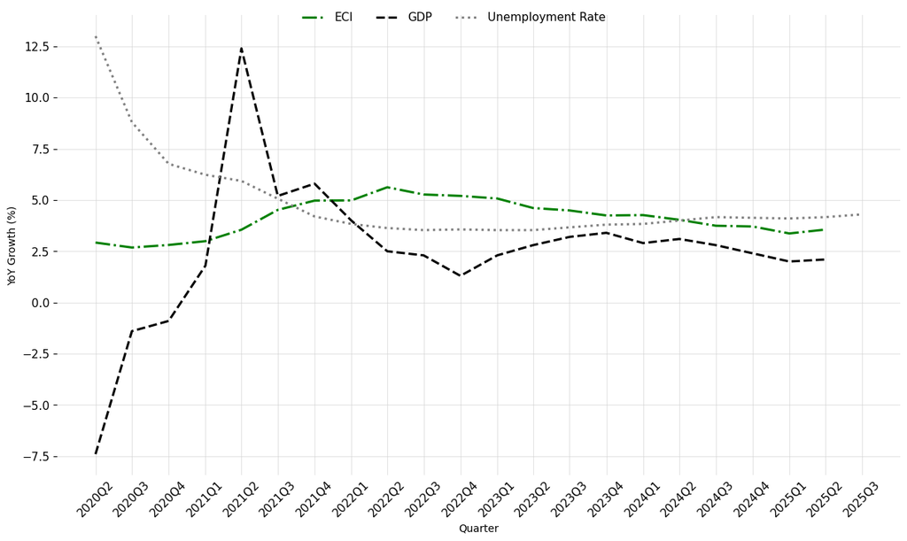

```python
eci           = pd.read_csv('./Data/public_data/ECIWAG.csv')
gdp_growth    = pd.read_csv('./Data/public_data/A191RO1Q156NBEA.csv')
unemployment  = pd.read_csv('./Data/public_data/UNRATE.csv')
participation = pd.read_csv('./Data/public_data/CIVPART.csv')

# Parse dates
eci['observation_date']           = pd.to_datetime(eci['observation_date'])
gdp_growth['observation_date']    = pd.to_datetime(gdp_growth['observation_date'])
unemployment['observation_date']  = pd.to_datetime(unemployment['observation_date'])
participation['observation_date'] = pd.to_datetime(participation['observation_date'])

eci['post_quarter']          = eci['observation_date'].dt.to_period('Q')
eci['eci_yoy'] = (
    eci['ECIWAG'].pct_change(4) * 100
)

eci                           = eci[['post_quarter', 'eci_yoy']]
gdp_growth['post_quarter']    = gdp_growth['observation_date'].dt.to_period('Q')
gdp_growth                    = gdp_growth[['post_quarter', 'A191RO1Q156NBEA']]
unemployment['post_quarter']  = unemployment['observation_date'].dt.to_period('Q')
participation['post_quarter'] = participation['observation_date'].dt.to_period('Q')

unemp_quarterly = (
    unemployment
    .groupby('post_quarter', as_index=False)['UNRATE']
    .mean()    # quarterly average unemployment rate
    .rename(columns={'UNRATE': 'unrate_us'})
)


part_quarterly = (
    participation
    .groupby('post_quarter', as_index=False)['CIVPART']
    .mean()    # quarterly average unemployment rate
    .rename(columns={'CIVPART': 'part_us'})
)
part_quarterly['part_yoy'] = (
    part_quarterly['part_us'].pct_change(4) * 100
)

macro_q = (
    eci
    .merge(gdp_growth,   on='post_quarter', how='outer')
    .merge(unemp_quarterly, on='post_quarter', how='outer')
    .merge(part_quarterly, on='post_quarter', how='outer')
)
macro_q['post_quarter_ts'] = macro_q['post_quarter'].dt.to_timestamp()
macro_q = macro_q.sort_values('post_quarter_ts')

macro_q_2020 = macro_q[ macro_q['post_quarter'] >= pd.Period('2020Q2') ]

print(macro_q_2020)

fig, ax = plt.subplots(figsize=(12, 7), constrained_layout=True)

# ---- Plot lines ----
ax.plot(
    macro_q_2020['post_quarter_ts'],
    macro_q_2020['eci_yoy'],
    label='ECI',
    linewidth=2.2,
    color='green',
    linestyle='-.'
)

ax.plot(
    macro_q_2020['post_quarter_ts'],
    macro_q_2020['A191RO1Q156NBEA'],
    label='GDP',
    linewidth=2.2,
    color='black',
    linestyle='--'
)

ax.plot(
    macro_q_2020['post_quarter_ts'],
    macro_q_2020['unrate_us'],
    label='Unemployment Rate',
    linewidth=2.2,
    color='gray',
    linestyle=':',
)

# ---- Axis labels ----
ax.set_xlabel("Quarter")
ax.set_ylabel("YoY Growth (%)")

# ---- Figure-level legend centered at the top ----
fig.legend(
    frameon=False,
    fontsize=11,
    loc="upper center",
    bbox_to_anchor=(0.5, 1.02),
    ncol=3
)

# ---- Remove all borders ----
for spine in ax.spines.values():
    spine.set_visible(False)

# ---- Grid ----
ax.grid(
    True,
    which='major',
    axis='both',
    color='lightgray',
    linewidth=0.8,
    alpha=0.6
)
ax.set_axisbelow(True)

# ---- X-axis tick formatting ----
macro_q_2020_sorted = (
    macro_q_2020
        .sort_values('post_quarter_ts')
        .drop_duplicates('post_quarter')
)

ax.set_xticks(macro_q_2020_sorted['post_quarter_ts'])
ax.set_xticklabels(macro_q_2020_sorted['post_quarter'].astype(str))

ax.tick_params(axis='x', length=0)
plt.xticks(rotation=45, fontsize=11)
plt.yticks(fontsize=11)

# ---- Save & show ----
save_and_show(out_path, "macro_vars.png")
```

## 3. Analyzing U.S. Labor Market Trends (openings, salaries, and job vacancy duration)

Using the LinkedIn job postings data. I analyze the U.S restricted version of the data for three variables: openings, salaries, and job vacancy duration for each sector. I plot annual moving averages for these three series, select the top three that exhibited the largest variation through the period, and compute a heatmap for all industries. I also incorporate the macroeconomic data at this point

## 3.1 Constructing the dataset for the Plots.

In the next code section, I prepare the data for plotting and determine the top three industries in terms of job opening variation.

```python
#Create a full quarterly date range
all_quarters = pd.period_range(
    start=postings_quarterly_type['post_quarter'].min(),
    end=postings_quarterly_type['post_quarter'].max(),
    freq='Q'
)

#Reindex each rics_k50 to include all quarters
def reindex_group(df):
    df = df.set_index('post_quarter').reindex(all_quarters)
    return df

postings_filled = (
    postings_quarterly_type
        .set_index(['rics_k50', 'post_quarter'])
        .groupby(level=0)
        .apply(lambda g: g.droplevel(0).reindex(all_quarters))
)

postings_filled.index = postings_filled.index.set_names(['rics_k50', 'post_quarter'])
postings_filled = postings_filled.reset_index()


postings_filled['postings'] = postings_filled['postings'].fillna(0)
# Compute total postings per rics_k50  (most aggregated)
postings_quarterly_type['post_quarter_ts'] = (
    postings_quarterly_type['post_quarter'].dt.to_timestamp()
)

# Sort for moving average
postings_filled = postings_filled.sort_values(['rics_k50', 'post_quarter'])
# Add a 4-quarter moving average (centered or trailing)
postings_filled['postings_ma4'] = (
    postings_filled
        .groupby('rics_k50')['postings']
        .transform(lambda s: s.rolling(window=4, min_periods=1).mean())
)

postings_filled['avg_salary_ma4'] = (
    postings_filled
        .groupby('rics_k50')['avg_salary']
        .transform(lambda s: s.rolling(window=4, min_periods=1).mean())
)

postings_filled['avg_duration_days_ma4'] = (
    postings_filled
        .groupby('rics_k50')['avg_duration_days']
        .transform(lambda s: s.rolling(window=4, min_periods=1).mean())
)

postings_filled['quarter_ts'] = postings_filled['post_quarter'].dt.to_timestamp()

# 1. Compute variation on smoothed value per rics_k50
variation = (
    postings_filled
      .groupby('rics_k50')['postings_ma4']
      .std()                      # or .var() for variance, .max()- .min() for range
      .sort_values(ascending=False)
)

# 2. Take the top N most variable categories
top_var_rics = variation.head(3).index.tolist()
#print(variation)
print("Most variable RICS_K50:", top_var_rics)

# 4. Filter postings_filled to just those categories
plot_data = postings_filled[postings_filled['rics_k50'].isin(top_var_rics)]


plot_data =(plot_data
    .merge(macro_q_2020[['post_quarter', 'eci_yoy', 'A191RO1Q156NBEA','unrate_us','part_yoy']],   on=['post_quarter'], how='left')
                         )

macro_for_plot = (
    plot_data
    .sort_values('quarter_ts')
    .drop_duplicates(subset=['quarter_ts'])
    [['quarter_ts', 'eci_yoy', 'A191RO1Q156NBEA', 'unrate_us','part_yoy']]
)
```

```
Most variable RICS_K50: ['Information Technology Services', 'Digital Commerce Services', 'Electronics Manufacturing']
```

## 3.2 Documenting Movement in Labor Market Trends.

In this section, I do all the plots documenting the domestic Labor Market Trends. First, I plot the annual moving average in job postings for all industries (heatmap) to see which industries had the largest cooling/heating in hiring relative to the historic average. I standardize the openings to their historical average, so I can interpret the colors in the heatmap as:

1. If the standardized openings are less than 1, then the openings have been lower in that quarter relative to their average.
2. If the standardized openings equal 1, then the openings have been at their average.
3. If the standardized openings are greater than 1, then the openings have been higher in that quarter relative to their average.

Moreover, this measure also highlights how far openings are from the historical average. For example, if the standardized openings equal 2, that means that openings have been twice as high as their historic average. Conversely, if the standardized openings equal 0.5, then the job openings have been half of their historical average.

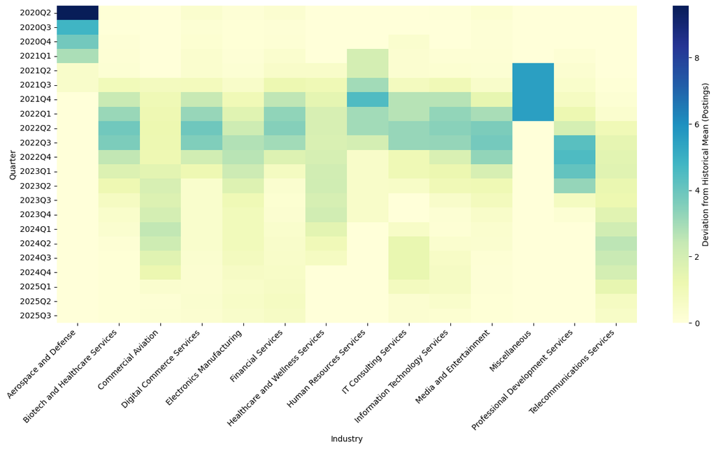

```python
pivot_postings = postings_filled.pivot_table(
    index='post_quarter',        # rows = quarters
    columns='rics_k50',          # columns = industries/roles
    values='postings_ma4',       # heat value (smoothed postings)
)
#pivot_dev = (pivot_postings - pivot_postings.mean()) / pivot_postings.std()
pivot_dev = pivot_postings / pivot_postings.mean()
#print(pivot_postings.mean() )
# Sort time for cleaner heatmap
pivot_postings = pivot_postings.sort_index()
#print(pivot_dev)
fig, ax = plt.subplots(figsize=(14, 8))

sns.heatmap(
    pivot_dev,
    cmap="YlGnBu",                      # no centering
    ax=ax,
    cbar_kws={"label": "Deviation from Historical Mean (Postings)"}
)

#ax.set_title("Job Postings by Industry (Deviation from Historical Mean, 4Q MA)", fontsize=14)
ax.set_xlabel("Industry")
ax.set_ylabel("Quarter")

# Rotate x-axis labels for readability
ax.set_xticklabels(
    pivot_postings.columns,
    rotation=45,
    ha="right"
)

plt.tight_layout()

save_and_show(out_path,"openings_heatmap.png")
```

Now, let's do the plot for the top three industries and compare these sectors against the GDP growth. Typically, job openings trail GDP growth so both can be used jointly to draw conclusions about the condition of the economy.

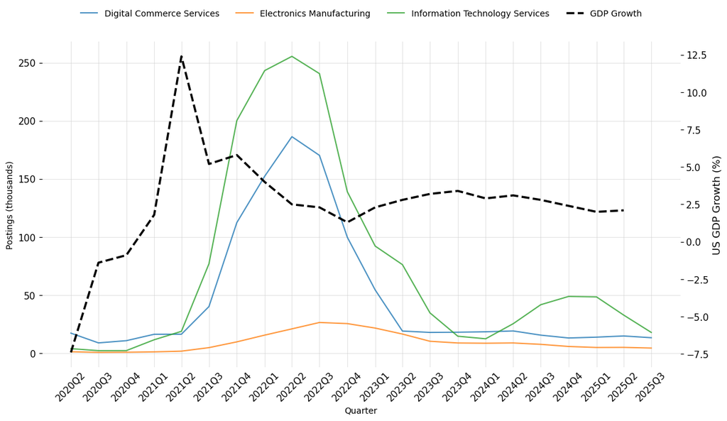

```python
plt.figure(figsize=(12, 7))

ax1 = plt.gca()

# ---- Remove ALL spines on primary axis ----
for spine in ax1.spines.values():
    spine.set_visible(False)

# ---- Primary axis: postings by rics_k50 ----
for rics in plot_data['rics_k50'].unique():
    subset = plot_data[plot_data['rics_k50'] == rics]
    ax1.plot(
        subset['quarter_ts'],
        subset['postings_ma4'],
        label=rics,
        alpha=0.8
    )

ax1.set_xlabel("Quarter")
ax1.set_ylabel("Postings (thousands)")
ax1.tick_params(axis='y', labelsize=11)
ax1.tick_params(axis='x', labelsize=11, rotation=45)

# ---- Use quarter strings as x-axis labels ----
# Sort by quarter_ts so ticks/labels are in order
plot_data_sorted = plot_data.sort_values('quarter_ts').drop_duplicates('quarter_ts')

ax1.set_xticks(plot_data_sorted['quarter_ts'])
ax1.set_xticklabels(plot_data_sorted['post_quarter'])

# ---- Light grid ----
ax1.grid(
    True,
    which='major',
    axis='both',
    color='lightgray',
    linewidth=0.8,
    alpha=0.6
)
ax1.set_axisbelow(True)
ax1.tick_params(axis='x', length=0)

# ---- Secondary axis: GDP YoY ----
ax2 = ax1.twinx()

ax2.plot(
    macro_for_plot['quarter_ts'],
    macro_for_plot['A191RO1Q156NBEA'],
    linestyle='--',
    linewidth=2.5,
    label='GDP Growth',
    color='black'
)

ax2.set_ylabel("US GDP Growth (%)", fontsize=12)
ax2.tick_params(axis='y', labelsize=11)

# ---- Remove ALL spines on secondary axis ----
for spine in ax2.spines.values():
    spine.set_visible(False)

# ---- Combined legend outside ----
lines1, labels1 = ax1.get_legend_handles_labels()
lines2, labels2 = ax2.get_legend_handles_labels()

ax1.legend(
    lines1 + lines2,
    labels1 + labels2,
    loc='lower center',
    bbox_to_anchor=(0.5, 1.05),
    ncol=len(labels1 + labels2),
    frameon=False,
    fontsize=10
)

plt.tight_layout()
save_and_show(out_path, "openings_top3.png")
```

Now, let's plot the annual moving average on salaries for these industries and overlay them against the ECI. The Employment Cost Index (ECI) measures the change in the hourly labor cost to employers over time. The ECI uses a fixed “basket” of labor to produce a pure cost change, free from the effects of workers moving between occupations and industries, and includes both the cost of wages and salaries and the cost of benefits. Therefore, comparing each industry wage trends against the ECI provides insight into how the cost of hiring for a sector fares against that one the whole economy.

*See* https://www.bls.gov/eci/

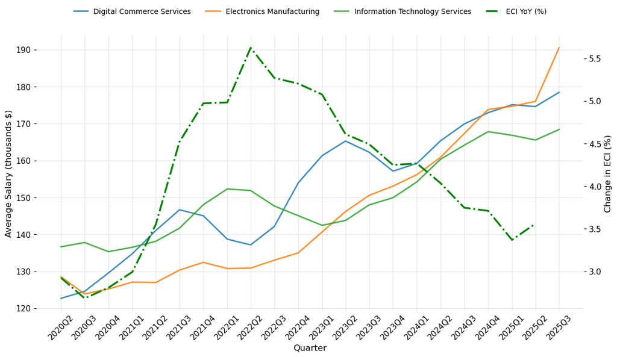

```python
# Plot average wages
plt.figure(figsize=(12, 7))

ax1 = plt.gca()

# ---- Primary axis: avg salary by rics_k50 ----
for rics in plot_data['rics_k50'].unique():
    subset = plot_data[plot_data['rics_k50'] == rics]
    ax1.plot(
        subset['quarter_ts'],
        subset['avg_salary_ma4'],
        label=rics,
        alpha=0.85,
        linewidth=2
    )

ax1.set_xlabel("Quarter", fontsize=12)
ax1.set_ylabel("Average Salary (thousands $)", fontsize=12)
ax1.tick_params(axis='y', labelsize=11)
ax1.tick_params(axis='x', rotation=45, labelsize=11)

# ---- Remove ALL spines on primary axis ----
for spine in ax1.spines.values():
    spine.set_visible(False)

# ---- Light gray grid ----
ax1.grid(
    True, which='major', axis='both',
    color='lightgray', linewidth=0.8, alpha=0.6
)
ax1.set_axisbelow(True)
ax1.tick_params(axis='x', length=0)
# ---- Secondary axis: ECI YoY ----
ax2 = ax1.twinx()
ax2.plot(
    macro_for_plot['quarter_ts'],
    macro_for_plot['eci_yoy'],
    linestyle='-.',
    linewidth=2.5,
    color='green',
    label='ECI YoY (%)'
)

ax2.set_ylabel("Change in ECI (%)", fontsize=12)
ax2.tick_params(axis='y', labelsize=11)

# ---- Remove ALL spines on secondary axis ----
for spine in ax2.spines.values():
    spine.set_visible(False)

# ---- Quarter labels on x-axis ----
plot_data_sorted = (
    plot_data
    .sort_values('quarter_ts')
    .drop_duplicates('quarter_ts')
)

ax1.set_xticks(plot_data_sorted['quarter_ts'])
ax1.set_xticklabels(plot_data_sorted['post_quarter'].astype(str))

# ---- Combined legend ABOVE the plot ----
lines1, labels1 = ax1.get_legend_handles_labels()
lines2, labels2 = ax2.get_legend_handles_labels()

ax1.legend(
    lines1 + lines2,
    labels1 + labels2,
    loc='lower center',
    bbox_to_anchor=(0.5, 1.05),
    ncol=len(labels1 + labels2),
    frameon=False,
    fontsize=10
)

plt.tight_layout()
save_and_show(out_path, "wages_openings_top3.png")
```

*See* https://www.bls.gov/cps/cps_htgm.htm

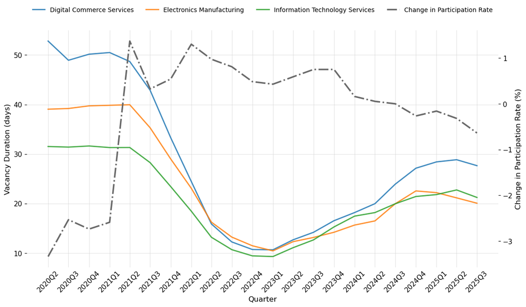

```python
# Plot average Job opening duration
plt.figure(figsize=(12, 7))

ax1 = plt.gca()

# ---- Primary axis: avg duration by rics_k50 ----
for rics in plot_data['rics_k50'].unique():
    subset = plot_data[plot_data['rics_k50'] == rics]
    ax1.plot(
        subset['quarter_ts'],
        subset['avg_duration_days_ma4'],
        label=rics,
        alpha=0.85,
        linewidth=2
    )

ax1.set_xlabel("Quarter", fontsize=12)
ax1.set_ylabel("Vacancy Duration (days)", fontsize=12)
ax1.tick_params(axis='y', labelsize=11)
ax1.tick_params(axis='x', rotation=45, labelsize=11)
ax1.tick_params(axis='x', length=0)
# ---- Remove ALL plot borders ----
for spine in ax1.spines.values():
    spine.set_visible(False)

# ---- Light gray grid ----
ax1.grid(
    True, which='major', axis='both',
    color='lightgray', linewidth=0.8, alpha=0.6
)
ax1.set_axisbelow(True)

# ---- Secondary axis: unemployment rate ----
ax2 = ax1.twinx()
ax2.plot(
    macro_for_plot['quarter_ts'],
    macro_for_plot['part_yoy'],
    linestyle='-.',
    linewidth=2.5,
    color='dimgray',
    label='Change in Participation Rate'
)

ax2.set_ylabel("Change in Participation Rate (%)", fontsize=12)
ax2.tick_params(axis='y', labelsize=11)

# ---- Remove ALL spines on secondary axis ----
for spine in ax2.spines.values():
    spine.set_visible(False)

# ---- Quarter labels on x-axis ----
plot_data_sorted = (
    plot_data
    .sort_values('quarter_ts')
    .drop_duplicates('quarter_ts')
)

ax1.set_xticks(plot_data_sorted['quarter_ts'])
ax1.set_xticklabels(plot_data_sorted['post_quarter'].astype(str))

# ---- Combined legend ABOVE the plot ----
lines1, labels1 = ax1.get_legend_handles_labels()
lines2, labels2 = ax2.get_legend_handles_labels()

ax1.legend(
    lines1 + lines2,
    labels1 + labels2,
    loc='lower center',
    bbox_to_anchor=(0.5, 1.05),
    ncol=len(labels1 + labels2),
    frameon=False,
    fontsize=10
)

plt.tight_layout()
save_and_show(out_path, "duration_openings_top3.png")
```

## 4. Documenting Movement in Labor Market Trends between the U.S and Other Labor Markets.

Now, I show how openings and duration move between the US vs these metrics abroad. These comparisons illustrate whether there is evidence of outsourcing jobs from one region to another, and may also document whether there is a global cooling off in the markets, rather than a localized one. First, I prepare the data for plotting

```python
# Convert quarterly Period for plotting
postings_quarterly_country['post_quarter_ts'] = (
    postings_quarterly_country['post_quarter'].dt.to_timestamp()
)
# Sort  teh data
postings_quarterly_country = postings_quarterly_country.sort_values(['country_group', 'post_quarter_ts'])
# 4-quarter moving averages by country_group
postings_quarterly_country['postings_ma4'] = (
    postings_quarterly_country
        .groupby('country_group')['postings']
        .transform(lambda s: s.rolling(window=4, min_periods=1).mean())
)

postings_quarterly_country['avg_salary_ma4'] = (
    postings_quarterly_country
        .groupby('country_group')['avg_salary']
        .transform(lambda s: s.rolling(window=4, min_periods=1).mean())
)

postings_quarterly_country['avg_duration_days_ma4'] = (
    postings_quarterly_country
        .groupby('country_group')['avg_duration_days']
        .transform(lambda s: s.rolling(window=4, min_periods=1).mean())
)

#display(postings_quarterly_country)
```

Now, let's plot the annual moving average between job postings in the U.S versus job postings in other countries. This comparison shows whether there is absorption from one region in hiring vacancies whenever there is a slowdown in hiring trends from another one. I also include the unemployment rate, which shows the general trend in the U.S Labor Markets.

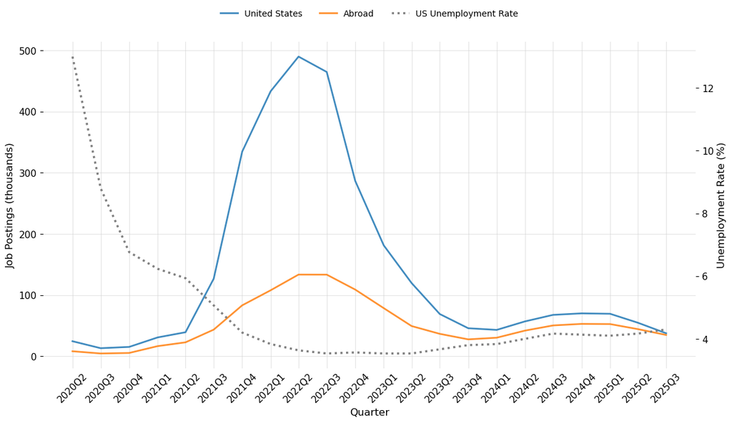

```python
plt.figure(figsize=(12, 7))
ax1 = plt.gca()

# ---- Primary axis: US vs Abroad postings ----
for region in ['United States', 'Abroad']:
    subset = postings_quarterly_country[
        postings_quarterly_country['country_group'] == region
    ]
    ax1.plot(
        subset['post_quarter_ts'],
        subset['postings_ma4'],
        label=region,
        linewidth=2,
        alpha=0.85
    )

ax1.set_xlabel("Quarter", fontsize=12)
ax1.set_ylabel("Job Postings (thousands)", fontsize=12)
ax1.tick_params(axis='y', labelsize=11)
ax1.tick_params(axis='x', rotation=45, labelsize=11)
ax1.tick_params(axis='x', length=0)
# ---- Remove ALL spines on primary axis ----
for spine in ax1.spines.values():
    spine.set_visible(False)

# ---- Light gray grid ----
ax1.grid(
    True, which='major', axis='both',
    color='lightgray', linewidth=0.8, alpha=0.6
)
ax1.set_axisbelow(True)
ax1.tick_params(axis='x', length=0)
# ---- Secondary axis: Unemployment rate ----
ax2 = ax1.twinx()
ax2.plot(
    macro_for_plot['quarter_ts'],
    macro_for_plot['unrate_us'],
    linestyle=':',
    linewidth=2.5,
    color='gray',
    label="US Unemployment Rate"
)

ax2.set_ylabel("Unemployment Rate (%)", fontsize=12)
ax2.tick_params(axis='y', labelsize=11)

# ---- Remove ALL spines on secondary axis ----
for spine in ax2.spines.values():
    spine.set_visible(False)

# ---- Quarter labels on x-axis ----
postings_sorted = (
    postings_quarterly_country
    .sort_values('post_quarter_ts')
    .drop_duplicates('post_quarter_ts')
)

ax1.set_xticks(postings_sorted['post_quarter_ts'])
ax1.set_xticklabels(postings_sorted['post_quarter'].astype(str))

# ---- Combined legend ABOVE plot ----
lines1, labels1 = ax1.get_legend_handles_labels()
lines2, labels2 = ax2.get_legend_handles_labels()

ax1.legend(
    lines1 + lines2,
    labels1 + labels2,
    loc='lower center',
    bbox_to_anchor=(0.5, 1.05),
    ncol=len(labels1 + labels2),
    frameon=False,
    fontsize=10
)

plt.tight_layout()
save_and_show(out_path, "openings_us_abroad.png")
```

Finally, let's plot the annual moving average between the average job vacancy duration in the U.S versus the average vacancy duration in other countries. If both series co-move, then this means that labor markets in the US and abroad cool (or heat) in synchrony. I also include the unemployment rate, which shows the general trend in the U.S Labor Markets.

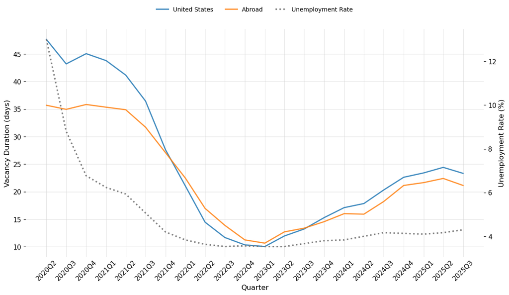

```python
plt.figure(figsize=(12, 7))
ax1 = plt.gca()

# ---- Primary axis: duration by region ----
for region in ['United States', 'Abroad']:
    subset = postings_quarterly_country[
        postings_quarterly_country['country_group'] == region
    ]
    ax1.plot(
        subset['post_quarter_ts'],
        subset['avg_duration_days_ma4'],
        label=region,
        linewidth=2,
        alpha=0.85
    )

ax1.set_xlabel("Quarter", fontsize=12)
ax1.set_ylabel("Vacancy Duration (days)", fontsize=12)
ax1.tick_params(axis='y', labelsize=11)
ax1.tick_params(axis='x', rotation=45, labelsize=11)

# ---- Remove ALL spines on primary axis ----
for spine in ax1.spines.values():
    spine.set_visible(False)

# ---- Grid behind data ----
ax1.grid(
    True, which='major', axis='both',
    color='lightgray', linewidth=0.8, alpha=0.6
)
ax1.set_axisbelow(True)
ax1.tick_params(axis='x', length=0)
# ---- Secondary axis: Unemployment rate ----
ax2 = ax1.twinx()
ax2.plot(
    macro_for_plot['quarter_ts'],
    macro_for_plot['unrate_us'],
    linestyle=':',
    linewidth=2.5,
    color='gray',
    label="Unemployment Rate"
)

ax2.set_ylabel("Unemployment Rate (%)", fontsize=12)
ax2.tick_params(axis='y', labelsize=11)

# ---- Remove ALL spines on secondary axis ----
for spine in ax2.spines.values():
    spine.set_visible(False)

# ---- Quarter labels on x-axis ----
postings_sorted = (
    postings_quarterly_country
    .sort_values('post_quarter_ts')
    .drop_duplicates('post_quarter_ts')
)

ax1.set_xticks(postings_sorted['post_quarter_ts'])
ax1.set_xticklabels(postings_sorted['post_quarter'].astype(str))

# ---- Combined legend ABOVE the plot ----
lines1, labels1 = ax1.get_legend_handles_labels()
lines2, labels2 = ax2.get_legend_handles_labels()

ax1.legend(
    lines1 + lines2,
    labels1 + labels2,
    loc='lower center',
    bbox_to_anchor=(0.5, 1.05),
    ncol=len(labels1 + labels2),
    frameon=False,
    fontsize=10
)

plt.tight_layout()
save_and_show(out_path, "duration_us_abroad.png")
```